# Robustness and Model Extensions

Profit Margins and the Business Cycle

# 1 Introduction

This report expands on previous analysis in order to determine whether the potential relationship between profit margins and the business cycle is robust. It does this through considering COVID-19 effects and adding additional regressors to explain the dynamic variation in margins across time.

The analysis includes:

- COVID-19 Dummy regression
- ARDL(2,1) estimation
- Long-run multipliers
- Residual diagnostics
- Model validation and comparison

# 2 Justification

## 2.1 COVID Period Evaluation

To determine whether COVID has made significant disruptions to the original elasticity model, we can include a COVID dummy into an augmented elasticity model.

$$D^{covid}_t =
\begin{cases}
1, & \text{if } 2020\text{Q1} \leq t \leq 2022\text{Q4} \\
0, & \text{otherwise}
\end{cases}$$

The augmented model;

$$\widehat{Margin}_{it} = \alpha_i + \beta_i Cycle_t + D^{covid}+v_{it}$$

To evaluate the impact of COVID-19, we can individually test for the statistical significance of the Dummy variable.

$$H_0 : D^{covid} = 0$$

$$H_1 : D^{covid} \neq 0$$

COVID Hypothesis Test

OLS Model: margin = bn + covid

| dataset | estimate | std_error | t_stat | p_value | decision | interpretation |
| --- | --- | --- | --- | --- | --- | --- |
| gop_gdp | 1.0399906 | 0.1531163 | 6.792161 | 1.110126e-09 | Reject H0 | COVID significantly affected margins |
| gop_thw | 0.9588069 | 0.1640168 | 5.845784 | 7.781991e-08 | Reject H0 | COVID significantly affected margins |
| gos_gdp | 1.9217008 | 0.3166533 | 6.068785 | 2.918353e-08 | Reject H0 | COVID significantly affected margins |
| gos_thw | 1.7188294 | 0.2935579 | 5.855163 | 7.469708e-08 | Reject H0 | COVID significantly affected margins |

As the calculated t-statistic exceeds the critical value, we can reject the null hypothesis that COVID-19 had no effect on the macroeconomic series, in favour of the alternative that it created a statistically significant distortion at all levels of confidence.

## 2.2 Significant Lag Identification

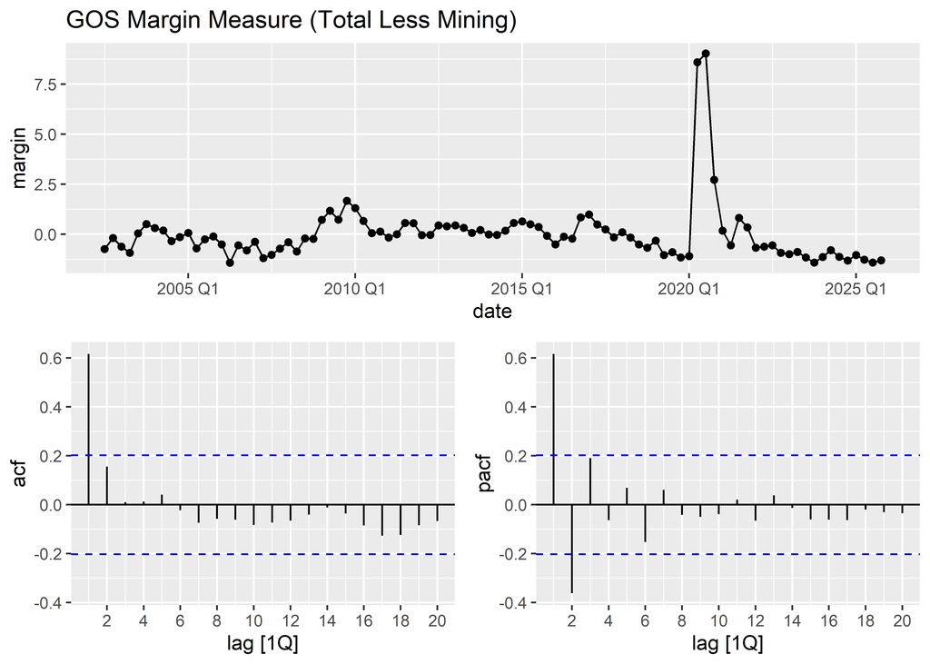

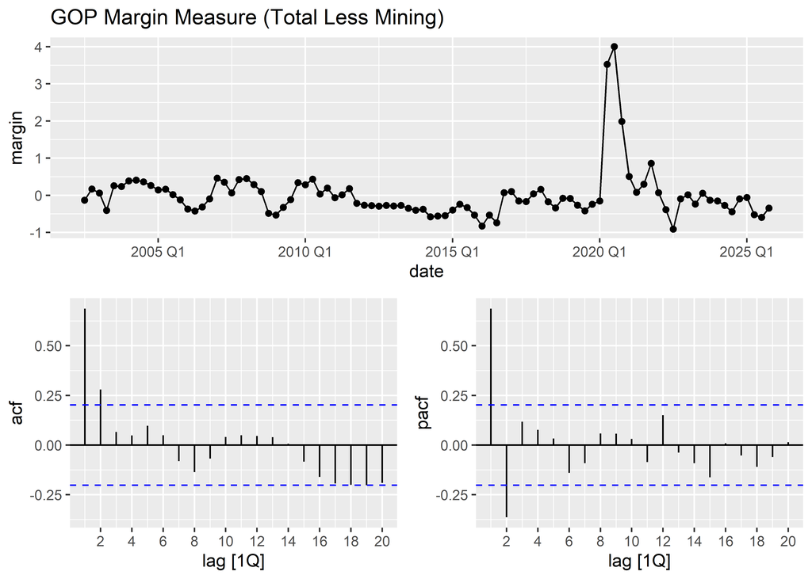

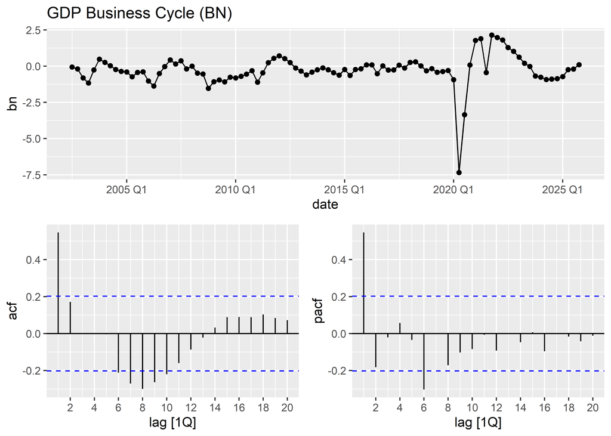

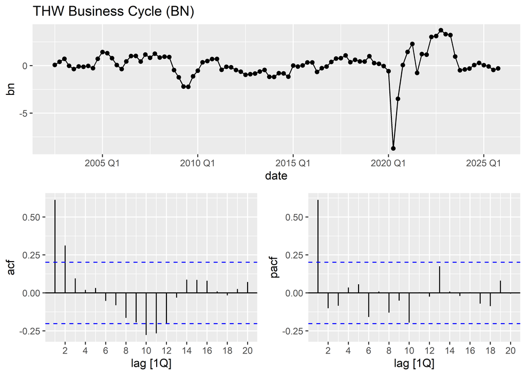

The PACF, which plots significant correlations in the lags of the respective variable, displays significant spikes beyond one period. This reflects that there is significant autocorrelation amongst the residuals that is not being explained in the current elasticity model.

In turn, the assumption of the OLS estimator and its standard errors are violated; leading to potential bias in the previous model’s estimates.  
We can rectify this omitted variable bias by including significant lags of each variable into an augmented model specification to hopefully capture more of the time dynamics of each series.

| Series | Number of significant lags |
| --- | --- |
| GOS | 2 |
| GOP | 2 |
| GDP | 1 |
| THW | 1 |

# 3 ARDL Specification

An Autoregressive Distributed Lag (ARDL) model explains variation in a variable using its own past values (autoregressive part) and current and past values of other variables (distributed lag part).

In simple terms, an ARDL model assumes that current outcomes depend both on:

1. Past behaviour of the variable itself
2. Delayed effects from explanatory variables.

As we previously identified two uniform significant lags for the margin series, and one significant lag for each macroeconomic series, we can estimate the following model;

$$\widehat{margin_t} =
\alpha +
\phi_1 \widehat{margin_{t-1}} +
\phi_2 \widehat{margin_{t-2}} +
\beta_0 bc_t +
\beta_1 bc_{t-1} +
\gamma D^{covid}_t+
u_t$$

## 3.1 Model Summaries

ARDL(2,1,0) Estimation Results

|  | gop_gdp | gop_thw | gos_gdp | gos_thw |
| --- | --- | --- | --- | --- |
| Margin (t-1) | 0.740*** | 0.950*** | 0.726*** | 0.767*** |
|  | (0.101) | (0.095) | (0.105) | (0.100) |
| Margin (t-2) | -0.240** | -0.372*** | -0.187* | -0.283*** |
|  | (0.083) | (0.083) | (0.075) | (0.067) |
| Business Cycle | -0.294*** | -0.244*** | -0.887*** | -0.699*** |
|  | (0.043) | (0.034) | (0.095) | (0.068) |
| Business Cycle (t-1) | 0.028 | 0.129** | 0.253+ | 0.266** |
|  | (0.054) | (0.040) | (0.134) | (0.100) |
| COVID Dummy | 0.575*** | 0.485*** | 0.992*** | 0.997*** |
|  | (0.128) | (0.127) | (0.266) | (0.239) |
| Num.Obs. | 92 | 92 | 92 | 92 |
| R2 | 0.770 | 0.757 | 0.779 | 0.807 |
| RMSE | 0.33 | 0.34 | 0.71 | 0.66 |

+ p < 0.1, * p < 0.05, ** p < 0.01, *** p < 0.001

`gop_gdp`: the GOP margin regressed on the cyclical component on GDP  
`gop_thw`: the GOP margin regressed on the cyclical component on THW  
`gos_gdp`: the GOS margin regressed on the cyclical component on GDP  
`gos_thw`: the GOS margin regressed on the cyclical component on THW

The augmented model shows potential, as majority of the results have statistical significance up to 99% confidence.

This is an economically intuitive result, as both costs and revenues are unlikely to change dramatically between adjacent quarters, all else constant. The consistently positive coefficient across all specifications indicates a robust relationship in which positive margins in the previous quarter are generally associated with positive margins in the current quarter. More broadly, this supports the notion that margins adjust gradually over time rather than instantaneously.

The estimated lagged margin term, $\widehat{margin}_{t-2}$, is negative and relatively small in magnitude across all specifications. This suggests that margins decline relative to levels observed two quarters prior. This is an important finding, as it supports the assumption that margins are cyclical and may potentially imply a half-year pattern. It also suggests that margins may revert toward some long-run equilibrium over time after expanding in the previous period. The estimate is economically reasonable given costs and revenues are only being fully adjusted or passed through after several quarters.

The coefficient $bc_t$ can still be interpreted as the partial elasticity of margins with respect to the business cycle. As such, these estimates can be compared directly with those from the original elasticity model (refer to the *Primary Analysis* document for further discussion). There is relatively little variation between the estimates of the two models. The GOP estimates exhibit a slightly larger magnitude (from approximately $-0.204$ to $-0.244$), while the GOS-THW estimate decreased by around $0.05$.

Where the ARDL specification truly shines is in identifying the longer-run effects of business cycle movements on margins, as $\widehat{bc}_{t-1}$ is positive across all specifications. Under the estimated models, stronger economic conditions in the previous quarter are associated with higher margins in the current quarter. This may suggest delayed pricing adjustment during periods of economic expansion, whereby firms respond gradually to increases in demand.

Assuming revenues are less sticky than costs, increases in economic activity may initially raise sales while wages, rents, and other input costs remain relatively fixed. This would place upward pressure on the denominator of the margin equations, compressing margins in the short run. Over time, however, firms may adjust prices or production structures, allowing margins to partially recover in subsequent quarters. Nevertheless, the relatively weaker statistical significance of these lagged coefficients remains a concern, as it suggests the evidence for delayed business-cycle effects on current margins is less robust.

The COVID-19 dummy variable aligns closely with the earlier visual analysis, as margins expanded considerably during this period across all specifications. The largest estimated effect is observed in the GOS specification, conditional on the cyclical component of THW.

Overall, the ARDL models suggest that business cycle expansions compress margins in the immediate term, while margins may partially recover after one quarter. This provides further evidence that the GOP and GOS measures are countercyclical, on average, with respect to fluctuations in the cyclical components of GDP and THW. Margins also display substantial short-run persistence, alongside cyclical fluctuations and potential mean reversion over approximately half-year periods.

# 4 Residual Diagnostics

## 4.1 Ljung-Box Test

The Ljung–Box test examines whether the residuals are independently distributed over time. In effect, it tests whether any remaining autocorrelation exists in the residuals across several lags.

$$H_0 : \text{No residual autocorrelation}$$

$$H_1 : \text{Residual autocorrelation exists}$$

A statistically insignificant result suggests that the residuals resemble white noise and that the model captures the dynamic structure of the data reasonably well.

Residual Diagnostic Tests

| dataset | lb_stat | lb_p |
| --- | --- | --- |
| gop_gdp | 10.80329 | 0.5458481 |
| gop_thw | 13.04208 | 0.3659898 |
| gos_gdp | 13.35834 | 0.3435416 |
| gos_thw | 13.77124 | 0.3155544 |

The Ljung–Box test results indicate that the null hypothesis of no residual autocorrelation cannot be rejected for any specification at conventional significance levels. All p-values are substantially greater than 0.05, suggesting that the residuals behave similarly to white noise. This provides evidence that the ARDL models adequately capture the dynamic structure of the data and that little systematic serial dependence remains in the residuals.

## 4.2 Breusch-Godfrey Test

The Breusch-Godfrey (BG) test also examines whether serial correlation remains in the regression residuals after accounting for the explanatory variables and lagged dependent variables.

$$H_0 : \text{No serial correlation in the residuals}$$

$$H_1 : \text{Serial correlation exists in the residuals}$$

A statistically insignificant result suggests that the model adequately captures the time-series dependence in the data.

Breusch-Godfrey Tests

| dataset | bg_stat | bg_p |
| --- | --- | --- |
| gop_gdp | 4.094420 | 0.39337827 |
| gop_thw | 8.566656 | 0.07289234 |
| gos_gdp | 7.284904 | 0.12157678 |
| gos_thw | 7.459561 | 0.11350578 |

The Breusch-Godfrey test results suggest that the null hypothesis of no serial correlation cannot be rejected for any model specification at the 5% significance level. This indicates that the ARDL models appear to adequately account for the time-series dependence in the data. While the GOP-THW specification produces a comparatively lower p-value, it still remains above conventional significance thresholds, providing only weak evidence of residual serial correlation.

## 4.3 Robust Standard Errors

To further validate the model, we can estimate its significance using HC1 standard errors.

Robust Standard Errors (HC1)

ARDL(2,1,0) Specifications

| Variable | Estimate | Robust SE | t-Statistic | p-Value |
| --- | --- | --- | --- | --- |
| gop_gdp |  |  |  |  |
| Constant | -0.148*** | 0.039 | -3.786 | 0.000 |
| `L(margin, 1)` | 0.74*** | 0.099 | 7.494 | 0.000 |
| `L(margin, 2)` | -0.24*** | 0.075 | -3.219 | 0.002 |
| Business Cycle | -0.294** | 0.112 | -2.611 | 0.011 |
| `L(bn, 1)` | 0.028 | 0.074 | 0.376 | 0.708 |
| COVID Dummy | 0.575** | 0.221 | 2.603 | 0.011 |
| gop_thw |  |  |  |  |
| Constant | -0.052 | 0.035 | -1.504 | 0.136 |
| `L(margin, 1)` | 0.95*** | 0.103 | 9.189 | 0.000 |
| `L(margin, 2)` | -0.372*** | 0.084 | -4.439 | 0.000 |
| Business Cycle | -0.244*** | 0.088 | -2.761 | 0.007 |
| `L(bn, 1)` | 0.129* | 0.066 | 1.939 | 0.056 |
| COVID Dummy | 0.485** | 0.225 | 2.157 | 0.034 |
| gos_gdp |  |  |  |  |
| Constant | -0.3*** | 0.086 | -3.486 | 0.001 |
| `L(margin, 1)` | 0.726*** | 0.122 | 5.932 | 0.000 |
| `L(margin, 2)` | -0.187* | 0.096 | -1.949 | 0.055 |
| Business Cycle | -0.887*** | 0.229 | -3.867 | 0.000 |
| `L(bn, 1)` | 0.253 | 0.156 | 1.618 | 0.109 |
| COVID Dummy | 0.992** | 0.399 | 2.486 | 0.015 |
| gos_thw |  |  |  |  |
| Constant | -0.079 | 0.066 | -1.194 | 0.236 |
| `L(margin, 1)` | 0.767*** | 0.149 | 5.157 | 0.000 |
| `L(margin, 2)` | -0.283*** | 0.087 | -3.262 | 0.002 |
| Business Cycle | -0.699*** | 0.175 | -3.989 | 0.000 |
| `L(bn, 1)` | 0.266 | 0.161 | 1.656 | 0.101 |
| COVID Dummy | 0.997** | 0.388 | 2.571 | 0.012 |

*** p < 0.01, ** p < 0.05, * p < 0.10

All regressors remain statistically significant except for the $bc_{t-1}$ , this is reasonable as it had lower statistical significance in the base model. This reinforces the notion that margins may not respond to changes in the cyclical component of GDP or THW directly after one period.

# 5 Residual Plots

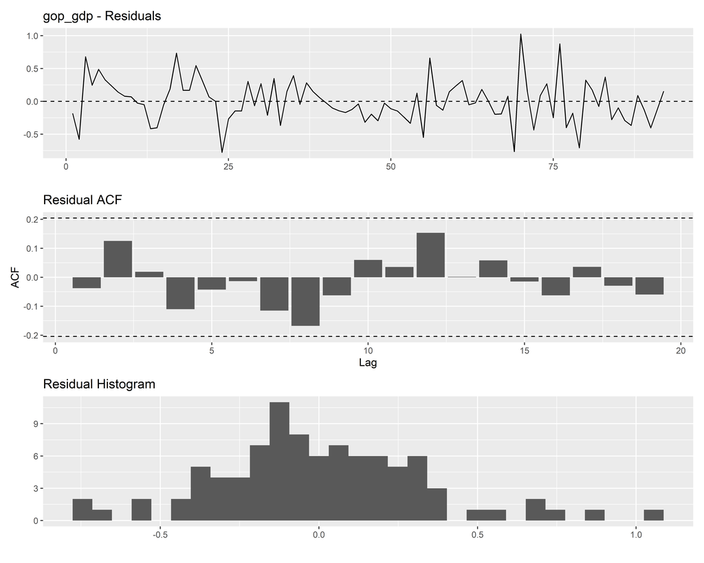

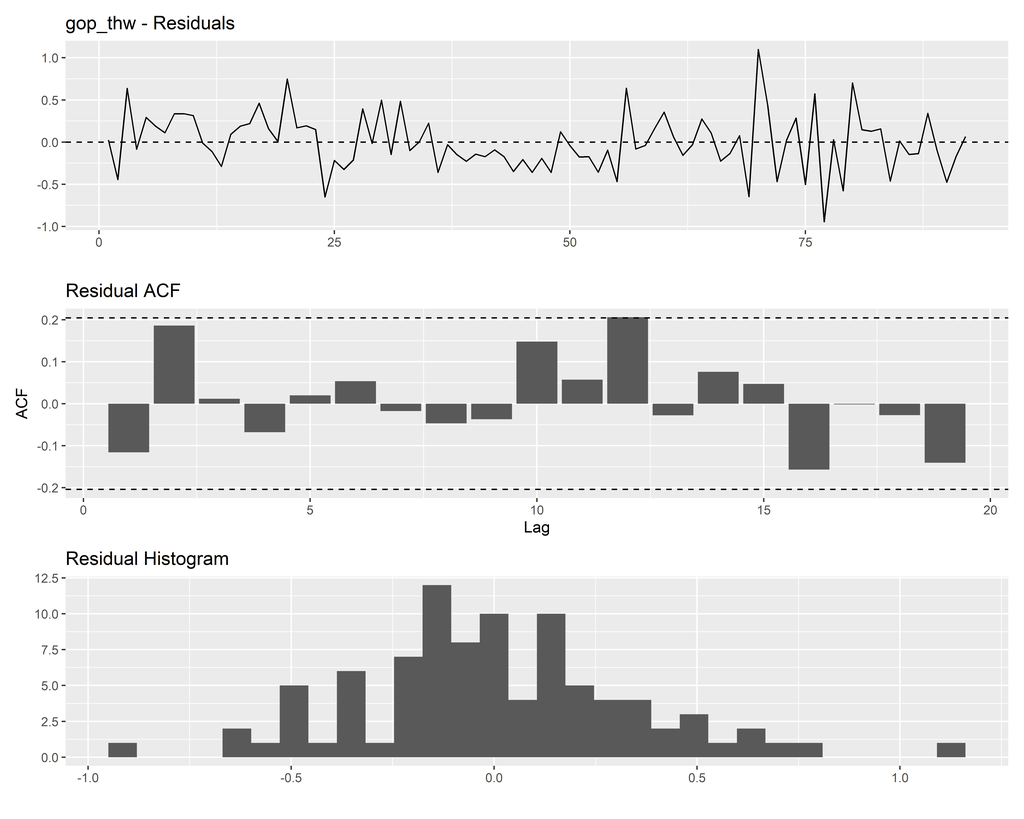

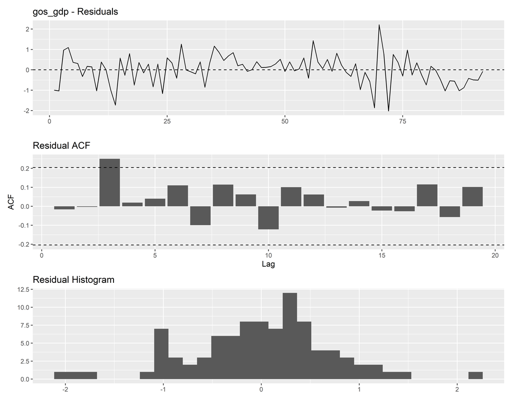

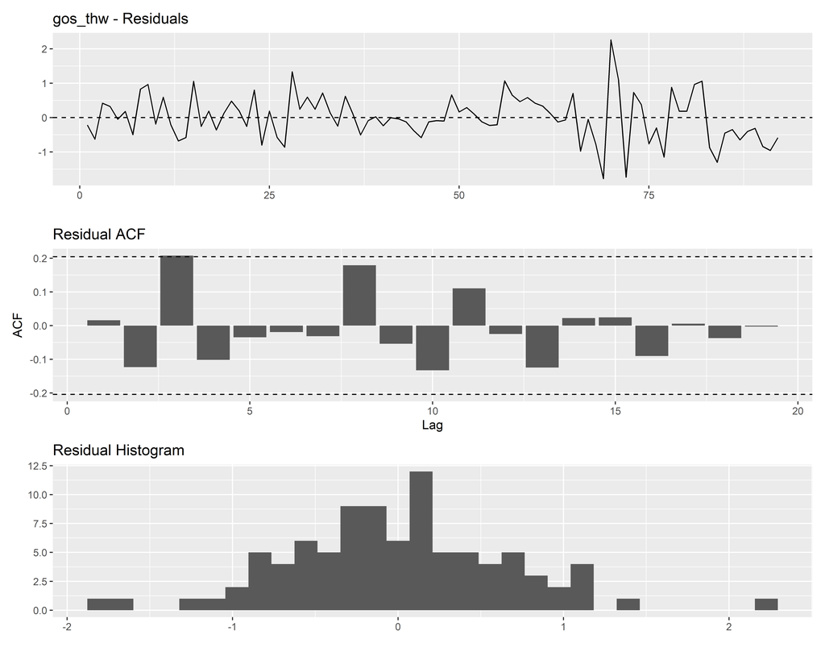

# 6 Model Comparison

This short section compares other potential ARDL specifications that could have been used and ranks them based on AIC and BIC scores.

ARDL Model Comparison

Models Ranked by AIC Within Each Dataset

| Model | AIC | BIC | AIC Rank |
| --- | --- | --- | --- |
| gop_gdp |  |  |  |
| ARDL(2,2) | 68.27 | 88.44 | 1 |
| Auto ARDL | 68.60 | 86.26 | 2 |
| ARDL(1,2) | 68.60 | 86.26 | 3 |
| ARDL(2,3) | 69.15 | 91.75 | 4 |
| ARDL(2,1) | 70.79 | 88.44 | 5 |
| gop_thw |  |  |  |
| ARDL(2,3) | 68.53 | 91.13 | 1 |
| ARDL(2,2) | 69.75 | 89.92 | 2 |
| Auto ARDL | 73.66 | 91.31 | 3 |
| ARDL(1,2) | 73.66 | 91.31 | 4 |
| ARDL(2,1) | 75.76 | 93.41 | 5 |
| gos_gdp |  |  |  |
| Auto ARDL | 195.83 | 218.33 | 1 |
| ARDL(2,3) | 199.13 | 221.73 | 2 |
| ARDL(1,2) | 202.74 | 220.39 | 3 |
| ARDL(2,2) | 204.73 | 224.90 | 4 |
| ARDL(2,1) | 212.24 | 229.89 | 5 |
| gos_thw |  |  |  |
| ARDL(2,3) | 188.20 | 210.80 | 1 |
| Auto ARDL | 195.92 | 218.41 | 2 |
| ARDL(2,2) | 197.93 | 218.10 | 3 |
| ARDL(1,2) | 198.84 | 216.49 | 4 |
| ARDL(2,1) | 199.80 | 217.46 | 5 |

# 7 Rolling Window Test

The rolling window stability test examines whether the relationship between margins and the business cycle remains stable over time. Rather than estimating a single model across the full sample, the ARDL model is repeatedly re-estimated over smaller moving subsamples, allowing the estimated business cycle coefficient to be tracked across different periods. For this exercise, we select a window of $60$ data points to provide a stricter stability test.

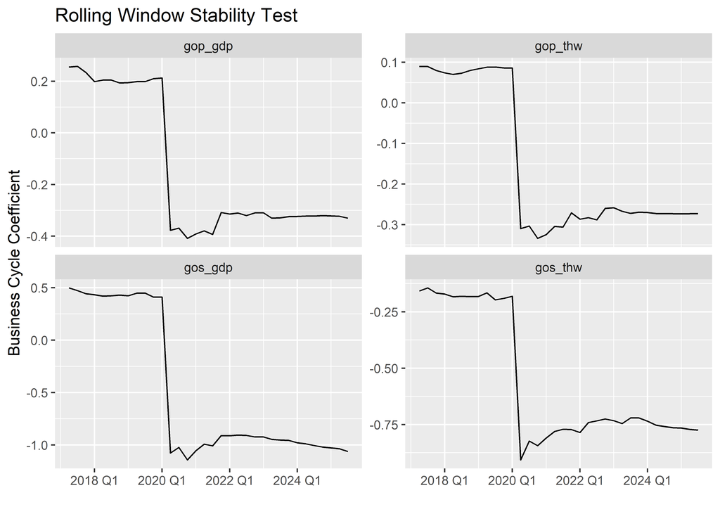

This partially contradicts the earlier full-sample ARDL results, which suggested a consistently negative relationship between margins and the business cycle across the entire sample. Instead, the rolling window results imply that the estimated countercyclicality is heavily influenced by the post-COVID period, indicating that the underlying relationship may not have been stable over time.

# 8 Conclusion

The analysis evaluated:

🎉 **Thank you for your support throughout this research project!**  
I hope you found the analysis and results as interesting and engaging as I did.

# 9 Appendix

## 9.1 Appendix 1: Long-Run multipliers

Under the ARDL framework, we can calculate the estimated long-run percentage response of margins to a sustained percentage change in the cyclical component variable.

Under this model, the long-run multiplier is:

$$\frac{\beta_0 + \beta_1}
{1 - \phi_1 - \phi_2}$$

Long-Run Multipliers

| dataset | long_run_multiplier |
| --- | --- |
| gop_gdp | -0.5313599 |
| gop_thw | -0.2728313 |
| gos_gdp | -1.3780509 |
| gos_thw | -0.8388090 |

This suggests that a permanent $1\%$ expansion in GDP is associated with negative long-run responses in both margin measures. The same relationship holds for THW, although the estimated magnitudes differ across specifications. The long-run multiplier is particularly useful in this context, as it estimates how margins respond as GDP converges toward its long-run or potential level, $Y^*$. GOS appears to be the most countercyclical, while GOP appears to be almost acyclical to THW in the LR. This may reflect the fact that less labour costs are included in the measure, making it less responsive to changes in labour market dynamics.

## 9.2 Appendix 2: Structural Break Tests

Structural Break Results

| dataset | n_breaks | breakpoints |
| --- | --- | --- |
| gop_gdp | 0 | NA |
| gop_thw | 0 | NA |
| gos_gdp | 0 | NA |
| gos_thw | 0 | NA |

## 9.3 Appendix 3: Actuals Vs. Fitted

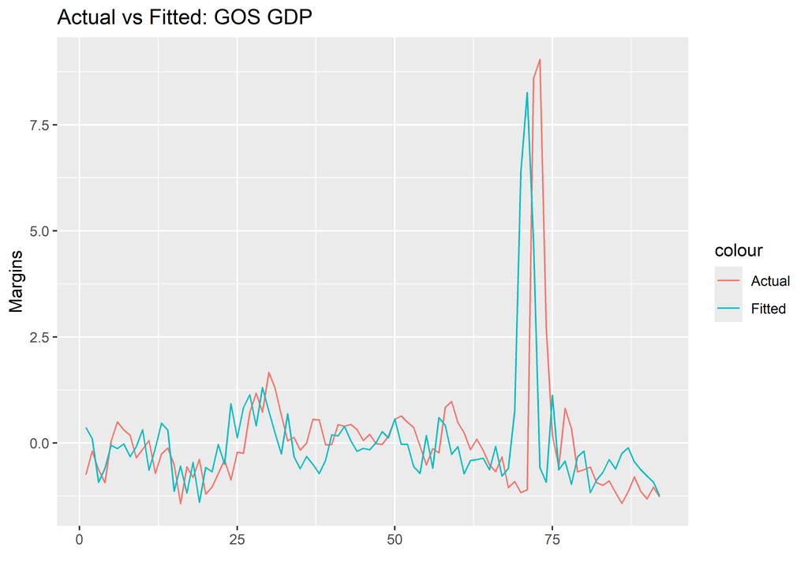

## 9.4 Appendix 4: Model Comparison: COVID Vs. No COVID

COVID Model Comparison

| dataset | model | AIC | BIC |
| --- | --- | --- | --- |
| gop_gdp | no_covid | 88.11227 | 103.24301 |
| gop_gdp | with_covid | 70.78906 | 88.44158 |
| gop_thw | no_covid | 88.22463 | 103.35536 |
| gop_thw | with_covid | 75.76170 | 93.41422 |
| gos_gdp | no_covid | 224.06894 | 239.19967 |
| gos_gdp | with_covid | 212.23724 | 229.88976 |
| gos_thw | no_covid | 214.71773 | 229.84846 |
| gos_thw | with_covid | 199.80491 | 217.45743 |

The AIC values are lower for all models that include COVID as a regressor. In effect, we can conclude that the COVID dummy variable is a significant contribution to the analysis.